# The Titanic

The sinking of the Titanic is one of the most infamous shipwrecks in history.

On April 15, 1912, during her maiden voyage, the widely considered “unsinkable” RMS Titanic sank after colliding with an iceberg. Unfortunately, there weren’t enough lifeboats for everyone onboard, resulting in the death of 1502 out of 2224 passengers and crew.

While there was some element of luck involved in surviving, it seems some groups of people were more likely to survive than others.

```python
import pandas as pd
import numpy as np
import matplotlib.pyplot as plt
import seaborn as sns
from scipy import stats
```

```python
# Load the dataset
titanic_df = pd.read_csv('train.csv')

# Preview the data
titanic_df.head()
```

|  | PassengerId | Survived | Pclass | Name | Sex | Age | SibSp | Parch | Ticket | Fare | Cabin | Embarked |
| --- | --- | --- | --- | --- | --- | --- | --- | --- | --- | --- | --- | --- |
| 0 | 1 | 0 | 3 | Braund, Mr. Owen Harris | male | 22.0 | 1 | 0 | A/5 21171 | 7.2500 | NaN | S |
| 1 | 2 | 1 | 1 | Cumings, Mrs. John Bradley (Florence Briggs Th... | female | 38.0 | 1 | 0 | PC 17599 | 71.2833 | C85 | C |
| 2 | 3 | 1 | 3 | Heikkinen, Miss. Laina | female | 26.0 | 0 | 0 | STON/O2. 3101282 | 7.9250 | NaN | S |
| 3 | 4 | 1 | 1 | Futrelle, Mrs. Jacques Heath (Lily May Peel) | female | 35.0 | 1 | 0 | 113803 | 53.1000 | C123 | S |
| 4 | 5 | 0 | 3 | Allen, Mr. William Henry | male | 35.0 | 0 | 0 | 373450 | 8.0500 | NaN | S |

Once the dataset is loaded, we can start cleaning and preprocessing the data. This involves removing any irrelevant columns, handling missing values, and converting columns to appropriate data types.

```python
# Remove any irrelevant columns
titanic_df = titanic_df.drop(['Cabin', 'Ticket'], axis=1)

# Handle missing values
titanic_df = titanic_df.fillna(0)

# Convert 'Sex' and 'Embarked' columns to category data type
titanic_df['Sex'] = titanic_df['Sex'].astype('category')
titanic_df['Embarked'] = titanic_df['Embarked'].astype('category')
```

This will create a dataframe with columns containing information on the passengers, such as their age, gender, class, and whether they survived the disaster.

Now that we have the data, let's move on to data management and representation. One way to represent the data is by creating visualizations. For example, we can create a bar plot to see the distribution of passenger class:

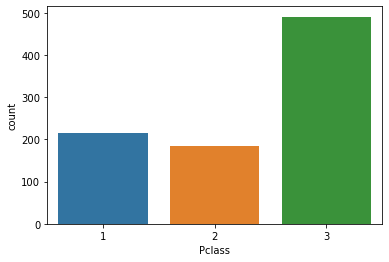

```python
# Create a bar plot
sns.countplot(x='Pclass', data=titanic_df)

# Show the plot
plt.show()
```

We can also create a histogram to see the distribution of ages:

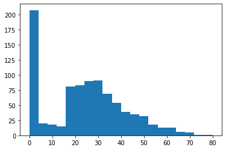

```python
# Create a histogram
plt.hist(titanic_df['Age'].dropna(), bins=20)

# Show the plot
plt.show()
```

let's add some more visualizations to help understand the data. For example, we can create a boxplot to see the distribution of ages by passenger class:

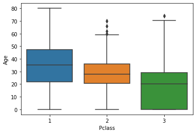

```python
# Create a boxplot
sns.boxplot(x='Pclass', y='Age', data=titanic_df)

# Show the plot
plt.show()
```

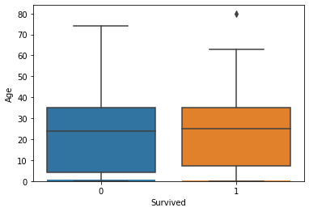

```python
import seaborn as sns

# Plot a barplot of the 'Sex' column
sns.barplot(x='Sex', y='Survived', data=titanic_df)

# Plot a boxplot of the 'Age' column
sns.boxplot(x='Survived', y='Age', data=titanic_df)
```

We can also create a bar plot to see the survival rate by passenger class:

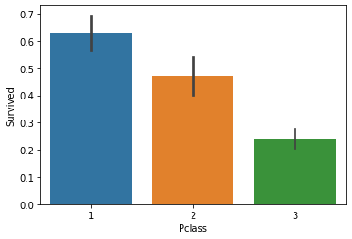

```python
# Create a bar plot
sns.barplot(x='Pclass', y='Survived', data=titanic_df)

# Show the plot
plt.show()
```

Next, let's move on to exploratory data analysis. One way to do this is by calculating some basic statistics for the data. For example, we can calculate the mean, median, and standard deviation for the age of the passengers:

```python
# Calculate statistics for the age feature
titanic_df['Age'].describe()
```

```
count    891.000000
mean      23.799293
std       17.596074
min        0.000000
25%        6.000000
50%       24.000000
75%       35.000000
max       80.000000
Name: Age, dtype: float64
```

We can also use a t-test to compare the means of continuous variables, such as age, between different groups of passengers. For example, we can test whether there is a significant difference in the mean ages of male and female passengers:

```python
# Test whether the mean age is different for male and female passengers
stats.ttest_ind(titanic_df[titanic_df['Sex'] == 'male']['Age'],
                titanic_df[titanic_df['Sex'] == 'female']['Age'])
```

```
Ttest_indResult(statistic=0.7449930237955704, pvalue=0.4564728382241444)
```

Next, let's move on to hypothesis testing. We can use statistical tests to determine whether there is a significant difference between the survival rates of different groups of passengers.

For example, we can use a chi-squared test to determine whether there is a significant difference in the survival rates of male and female passengers:

```python
# Create a contingency table
contingency_table = pd.crosstab(titanic_df['Sex'], titanic_df['Survived'])

# Perform a chi-squared test
chi2, p, dof, expected = stats.chi2_contingency(contingency_table)

# Print the p-value
print(p)
```

```
1.1973570627755645e-58
```

```python
# Import the linear regression model
from sklearn.linear_model import LinearRegression

# Create the model
model = LinearRegression()

# Fit the model to the data
model.fit(titanic_df[['Age']], titanic_df['Fare'])

# Print the model's coefficients
print(f'Slope: {model.coef_[0]:.3f}')
print(f'Intercept: {model.intercept_:.3f}')
```

```
Slope: 0.383
Intercept: 23.096
```

# Conclusion:

The Titanic disaster remains one of the most infamous maritime tragedies in history, with over 1500 lives lost in the freezing waters of the North Atlantic. While the sinking of the ship was caused by a variety of factors, including the impact of the iceberg and the inadequate safety measures in place, the survival rate of passengers varied widely.

Despite these nuances, the insights attained from the Titanic dataset provide a valuable perspective on the factors that influenced the survival of passengers on the fateful voyage. Further research and analysis could delve deeper into these factors and their specific effects on survival rate, as well as examine the broader social and cultural context in which the disaster took place. Ultimately, understanding the patterns and trends revealed by this data can help to inform future disaster preparedness and response efforts, ensuring that the lessons of the Titanic are not forgotten.